# EP05-respuesta-equipo-1

2025-04-20

## Contexto:

#### En una emocionante competencia de cubos Rubik, participantes de Chile, Argentina, Colombia, Uruguay, Perú y Ecuador demostraron su destreza en resolver tres tipos de cubos: 2x2x2, 3x3x3 y Megaminx. Después del torneo, un grupo de investigadores de la Asociación Mundial del Cubo, interesado en los tiempos que hicieron las jugadoras y los jugadores en la competencia, decidieron estudiar si el país y el tipo de cubo usado en cada prueba tienen influencia en los segundos que se tardan en resolverlos. Para ello usaron una muestra aleatoria de los datos de la competencia, en la cual participaron más de 2.000 personas

#### Las variables presentes en la muestra son las siguientes:

| Variable | Tipo |
| --- | --- |
| id | Cuantitativa Discreta |
| pais | Cualitativa Nominal |
| tipo | Cualitativa Nominal |
| tiempo | Cuantitativa Continua |

## Pregunta:

#### ¿Existen diferencias en el tiempo de resolución de cubos 2x2x2 entre participantes de Chile, Perú y Argentina?

## Solución:

```r
# Lectura del archivo csv
data = read.csv2("EP05 Datos.csv")
```

```r
# Agrupacion de los datos
tiempos2x2x2<- data %>% filter(tipo=="2x2x2")
tiempos2x2x2<- tiempos2x2x2 %>% filter(pais=="Chile"|pais=="Perú"|pais=="Argentina")
tiempos2x2x2[["id"]]<- factor(tiempos2x2x2[["id"]])
tiempos2x2x2[["pais"]]<- factor(tiempos2x2x2[["pais"]])
tiempos2x2x2<-tiempos2x2x2%>%select(id,pais,tiempo)


datoschile<- tiempos2x2x2 %>% filter(pais=="Chile") %>% select(id,pais,tiempo)
datosperu<- tiempos2x2x2 %>% filter(pais=="Perú") %>% select(id,pais,tiempo)
datosargentina<- tiempos2x2x2 %>% filter(pais=="Argentina") %>% select(id,pais,tiempo)
```

##### Verificando los requerimientos para utilizar ANOVA ómnibus para pruebas independientes:

##### 1)La escala con que se mide la variable dependiente tiene las propiedades de una escala de intervalos.

##### 2)Las k muestras son obtenidas de manera aleatoria e independiente desde la poblacion de origen.

##### 3)Se puede suponer razonablemente que la poblacion tiene una distribucion normal.

##### 4)Si las muestras provienen de mas de una poblacion, estas poblaciones tienen la misma parianza.

##### Dentro del contexto de la pregunta, la primera condición se cumple debido a que es una variable continua de datos, además que la diferencia de 2 valores es conocida y constante (diferencia entre 5s y 10s es 5s, al igual que 10s y 15s, etc). Respecto a la aleatoriedad e independencia de las observaciones, esto se afirma en el enunciado: “Para ello usaron una muestra aleatoria de los datos de la competencia”. Para concluir sobre la normalidad se puede utilizar los graficos Q-Q.

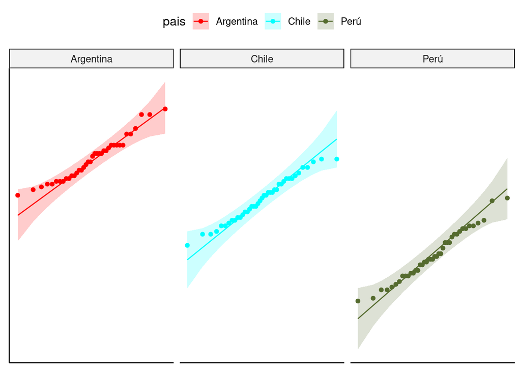

```r
g<- ggqqplot(tiempos2x2x2,x="tiempo",y="pais", color = "pais", palette=c("red1","cyan1","darkolivegreen"))

# Cada categoria genera un grafico
g<- g +facet_wrap(~ pais)
g<- g + rremove("x.ticks") + rremove("x.text")
g<- g + rremove("y.ticks") + rremove("y.text")
g<- g + rremove("axis.title")
print(g)
```

##### Dentro de todo, se puede ver en el gráfico que las muestras de cada pais se acercan bastante a una distribucion normal, con uno que otro dato mas alejado, por lo que se puede concluir que la población de origen sigue una distribución normal y se sigue un nivel de significancia de 0.05.

##### -Shapiro test para Chile

```r
shapirochile<-shapiro.test(datoschile$tiempo)
print(shapirochile)
```

```
##
##  Shapiro-Wilk normality test
##
## data:  datoschile$tiempo
## W = 0.97831, p-value = 0.6119
```

##### -Shapiro test para Argentina

```r
shapiroargentina<-shapiro.test(datosargentina$tiempo)
print(shapiroargentina)
```

```
##
##  Shapiro-Wilk normality test
##
## data:  datosargentina$tiempo
## W = 0.95646, p-value = 0.1453
```

##### -Shapiro test para Peru

```r
shapiroperu<-shapiro.test(datosperu$tiempo)
print(shapiroperu)
```

```
##
##  Shapiro-Wilk normality test
##
## data:  datosperu$tiempo
## W = 0.97779, p-value = 0.5926
```

##### En todas las instancias del test de shapiro se obtiene un valor mayor a 0.05, por lo cual podemos concluir que efectivamente los datos siguen una distribución normal.

##### Ahora, con respecto a la ultima condición, se debe obtener la varianza de las muestras de cada país.

```r
varia<-aggregate(tiempo~pais,data=tiempos2x2x2,var)
print(varia$tiempo[3]/varia$tiempo[1])
```

```
## [1] 1.338323
```

##### Ya concluido que se puede utilizar el test de ANOVA, se plantean las hipotesis:

##### -H0 = No hay diferencia significativa en las medias de los tiempos de solución entre los 3 países.

##### -Ha = Existe diferencia significativa en las medias de los tiempos de solución entre los 3 países.

Estas hipótesis expresadas matemáticamente:

##### H0:μChile=μPeru=μArgentina

##### Ha: ∃(i,j) tal que μi != μj, con i, j ∈ {Chile, Peru, Argentina}, i != j

```r
pruebaANOVA<-ezANOVA(tiempos2x2x2,dv=tiempo,wid=id,between=pais, return_aov = TRUE)
```

```
## Coefficient covariances computed by hccm()
```

```r
print(pruebaANOVA)
```

```
## $ANOVA
##   Effect DFn DFd        F            p p<.05       ges
## 1   pais   2 117 170.4814 2.139484e-35     * 0.7445207
##
## $`Levene's Test for Homogeneity of Variance`
##   DFn DFd         SSn       SSd         F         p p<.05
## 1   2 117 0.001546624 0.2647834 0.3417038 0.7112653
##
## $aov
## Call:
##    aov(formula = formula(aov_formula), data = data)
##
## Terms:
##                      pais Residuals
## Sum of Squares  2.3898519 0.8200681
## Deg. of Freedom         2       117
##
## Residual standard error: 0.08372054
## Estimated effects may be unbalanced
```

##### Se obtiene un p-value de 2.139484e-35 mucho menor que el alfa = 0.05, lo que nos permite concluir que si existe una diferencia significativa entre las medias de al menos un par entre los 3 países, para ver en cual país existe esta diferencia se debe usar un procedimiento de Post Hoc, para esto se empleará la prueba HSD de Tukey.

```r
hsd<-TukeyHSD(pruebaANOVA$aov, "pais",ordered=TRUE)
print(hsd,digits=15)
```

```
##   Tukey multiple comparisons of means
##     95% family-wise confidence level
##     factor levels have been ordered
##
## Fit: aov(formula = formula(aov_formula), data = data)
##
## $pais
##                              diff                lwr               upr
## Chile-Perú      0.201707317073171 0.1578118573805330 0.245602776765809
## Argentina-Perú  0.345629011553274 0.3008755789962100 0.390382444110337
## Argentina-Chile 0.143921694480103 0.0991682619230388 0.188675127037166
##                      p adj
## Chile-Perú      3.1000e-14
## Argentina-Perú  1.3000e-14
## Argentina-Chile 2.0283e-11
```